# belief-prior-exp

mht

September 8, 2014

This report looks at the data elicited from 03syllogism-prior-exp. We asked people about the plausibility or frequency of various combinations of objects occurring. This is the so-called *prior elicitation* part of the experiment.

Let’s start with the RT distribution. This is the time to complete the 8-state multinomial elicitation.

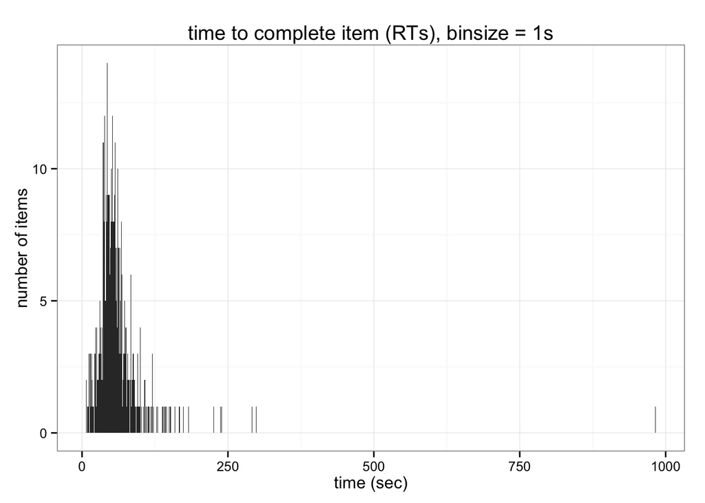

```r
library(ggplot2)
library(reshape2)


fpath = '/Users/mht/Documents/research/syllogism/data/03syllogism_prior_psychjs/'

df<-read.csv((paste(fpath,'prior-exp-mturk_all_n71.csv',sep="")))[c(1:12,16)]
df$condition<-factor(df$condition,labels=c('plausibility','frequency'))

ggplot(df, aes(x=(rt/1000)))+
  geom_histogram(binwidth=1)+
  theme_bw()+
  ggtitle("time to complete item (RTs), binsize = 1s")+
  xlab('time (sec)')+
  ylab('number of items')
```

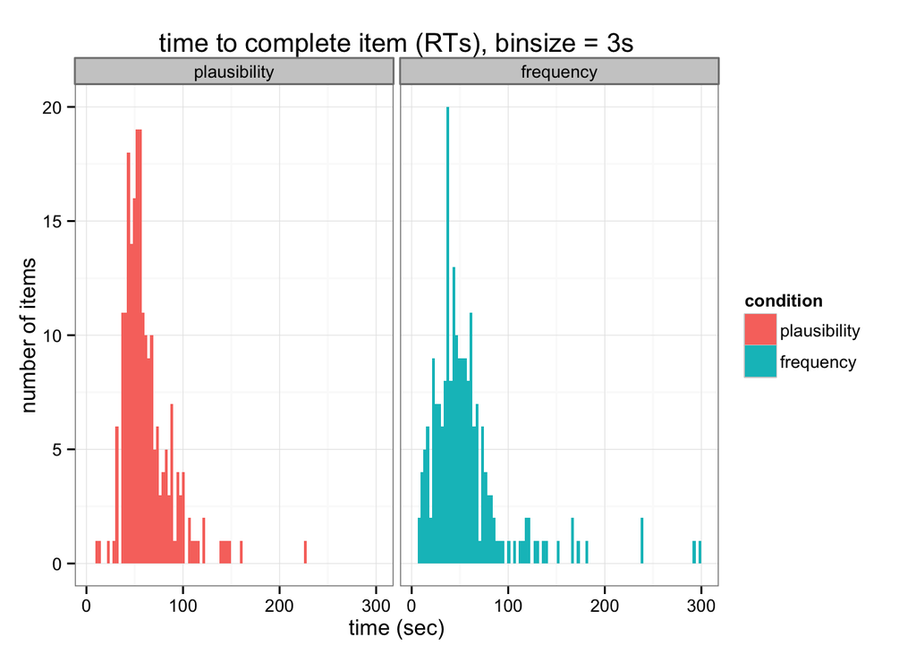

```r
df<-subset(df,rt<500000)

ggplot(df, aes(x=(rt/1000),fill=condition))+
  geom_histogram(binwidth=3)+
  theme_bw()+
  facet_wrap(~condition)+
  ggtitle("time to complete item (RTs), binsize = 3s")+
  xlab('time (sec)')+
  ylab('number of items')
```

Looks like one person fell asleep in the chair. Otherwise, normalish around 50seconds per 8 state elicitation. Reasonable.

### raw slider value distribution

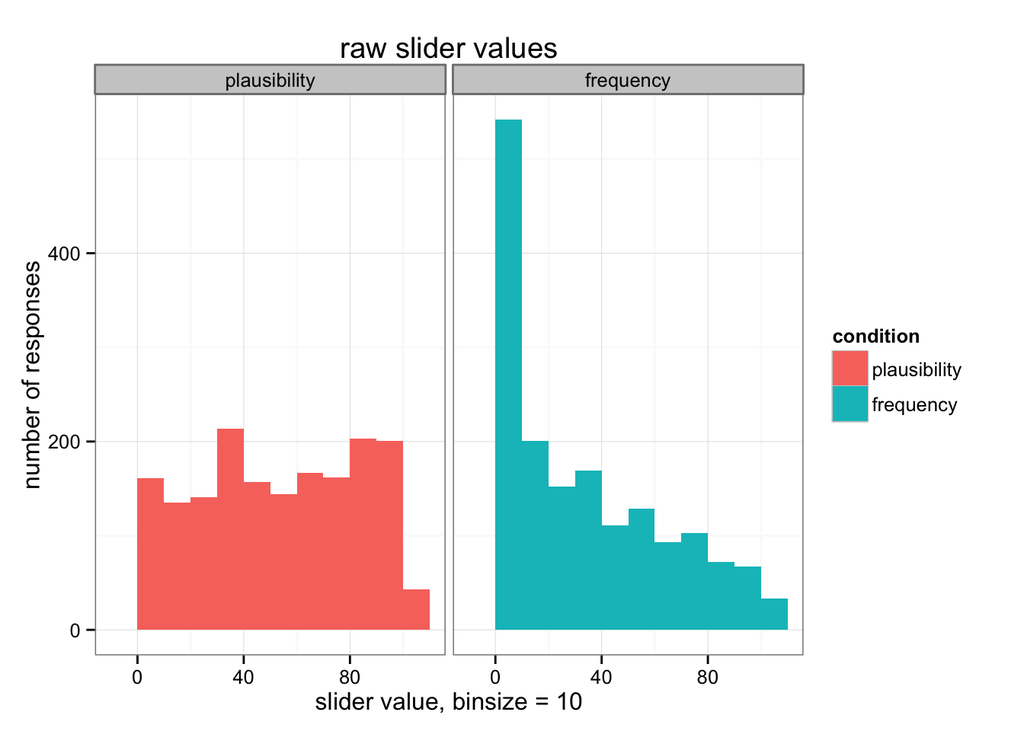

```r
ggplot(melt(df[3:11]), aes(x=value,fill=condition))+
  geom_histogram(binwidth=10)+
  facet_wrap(~condition)+
  theme_bw()+
  ggtitle('raw slider values')+
  xlab('slider value, binsize = 10')+
  ylab('number of responses')
```

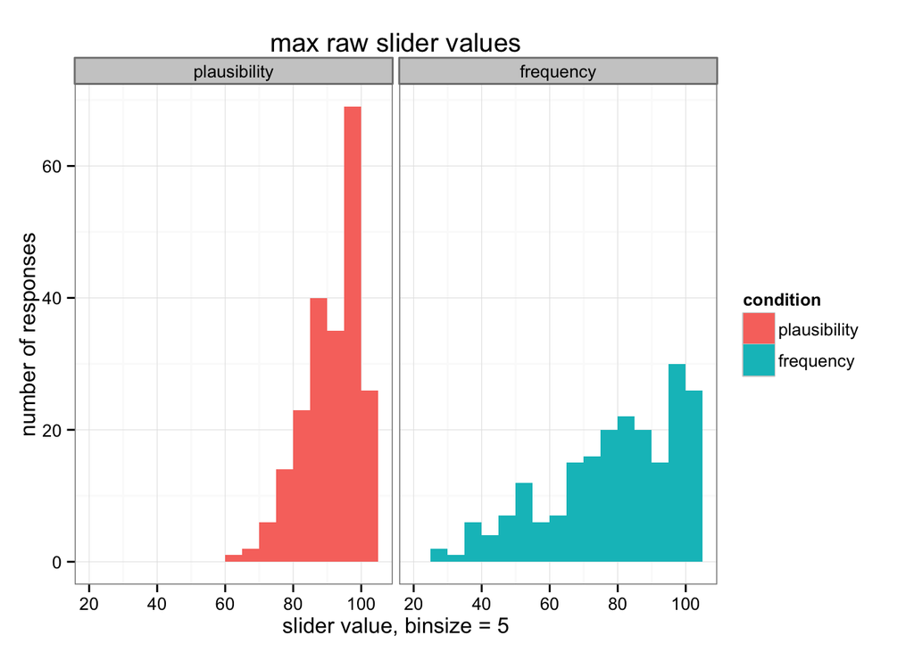

```r
property_labels <- c('Q_XYZ','Q_XYnZ','Q_XnYZ','Q_nXYZ','Q_XnYnZ','Q_nXYnZ','Q_nXnYZ','Q_nXnYnZ')

df$sum<-rowSums(df[,property_labels])
df$max<-apply(df[,property_labels],1,max)

ggplot(melt(df[c('condition','max')]), aes(x=value,fill=condition))+
  geom_histogram(binwidth=5)+
  facet_wrap(~condition)+
  theme_bw()+
  ggtitle('max raw slider values')+
  xlab('slider value, binsize = 5')+
  ylab('number of responses')
```

[with n=29 for plausibility and n=21 for frequency] the frequency distribution appears exponential while the plausibility distribution appears uniform. There are many more 0 responses for the frequency prompt. This in unnormalized data remember.

### Raw sum distributions

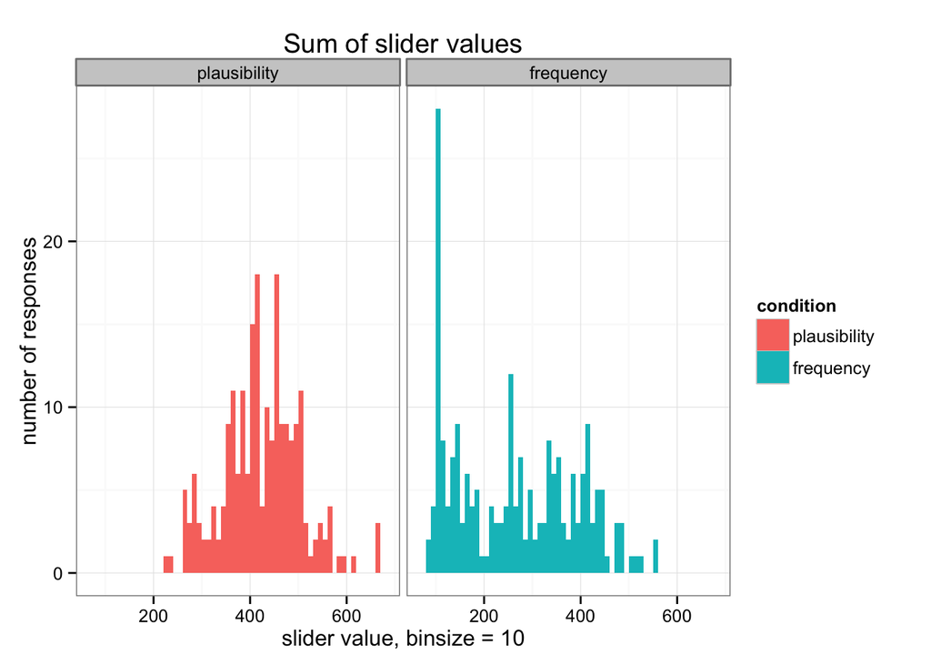

```r
ggplot(melt(df[c('condition','sum')]), aes(x=value,fill=condition))+
  geom_histogram(binwidth=10)+
  facet_wrap(~condition)+
  theme_bw()+
  ggtitle('Sum of slider values')+
  xlab('slider value, binsize = 10')+
  ylab('number of responses')
```

Raw sums of plausibility elicitations are normalish around 400. This is (by coincidence?) 8 (state) * 100 / 2, fyi.

Frequency doesn’t show this. Instead, we get a great number which sum to approximately 100, and others that go beyond.

**mini-hypothesis: the sum=100 responses occur when max response is near 100, i.e. when the 8-state is {100, 0, 0, 0, 0, 0, 0, 0}.** We’re going to plot the max response vs. the sum of responses, for each item.

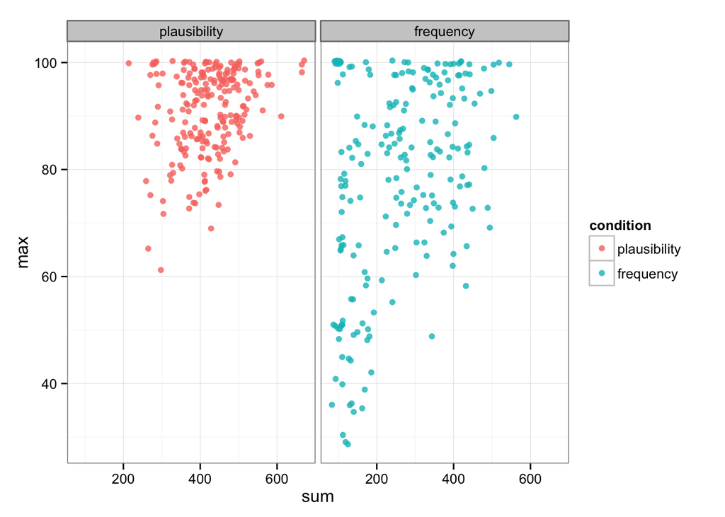

```r
ggplot(df[c('condition','sum','max')],aes(x=sum,y=max,color=condition))+
  geom_point(alpha=0.8,position=position_jitter(10))+
  facet_wrap(~condition)+
  theme_bw()
```

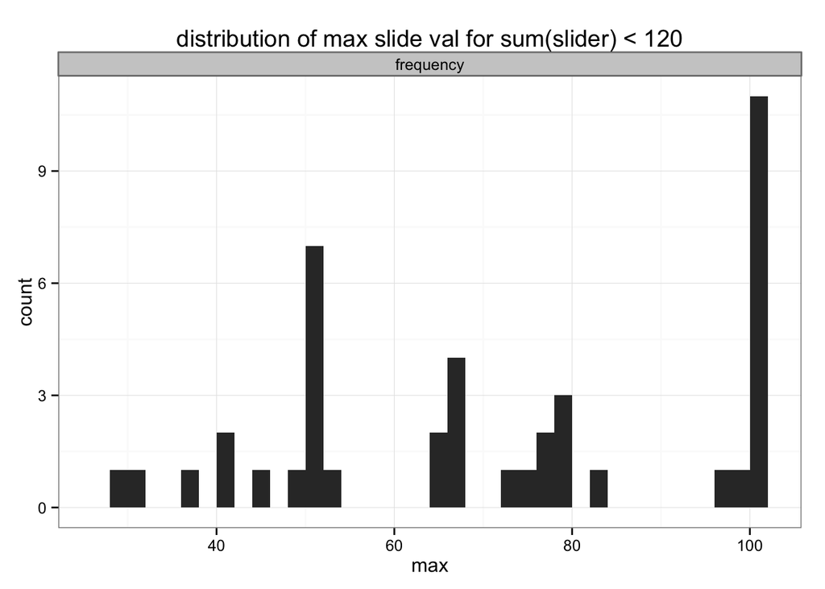

```r
ggplot(subset(df,sum<120),aes(x=max))+
  geom_histogram(binwidth=2)+
  facet_wrap(~condition)+
  theme_bw()+
  ggtitle('distribution of max slide val for sum(slider) < 120')
```

### normalized slider value distribution

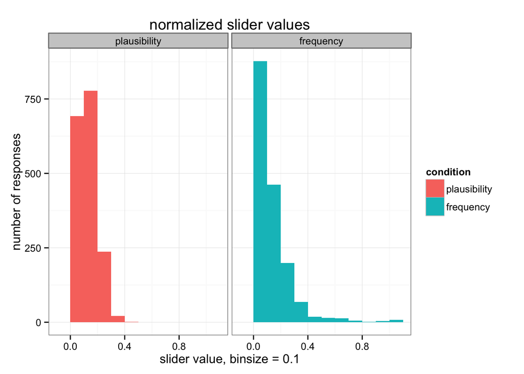

```r
df_norm = ddply(df, .(domain, condition), function(x) {
  means = x[,c('Q_XYZ','Q_XYnZ','Q_XnYZ','Q_nXYZ','Q_XnYnZ','Q_nXYnZ','Q_nXnYZ','Q_nXnYnZ')]
  means / rowSums(means)
})

ggplot(melt(df_norm), aes(x=value,fill=condition))+
  geom_histogram(binwidth=0.1)+
  facet_wrap(~condition)+
  theme_bw()+
  ggtitle('normalized slider values')+
  xlab('slider value, binsize = 0.1')+
  ylab('number of responses')
```

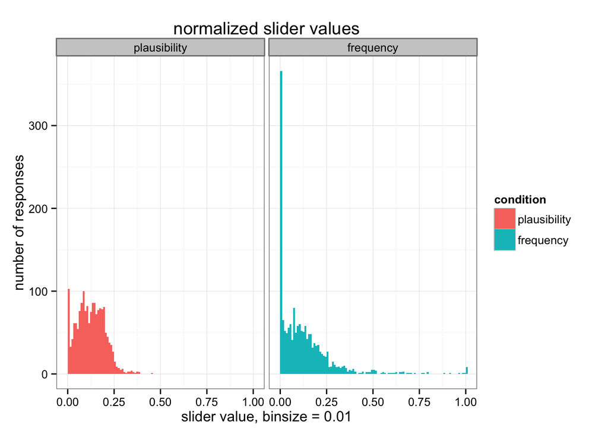

```r
ggplot(melt(df_norm), aes(x=value,fill=condition))+
  geom_histogram(binwidth=0.01)+
  facet_wrap(~condition)+
  theme_bw()+
  ggtitle('normalized slider values')+
  xlab('slider value, binsize = 0.01')+
  ylab('number of responses')
```

[with n=29 for plausibility and n=21 for frequency] both distributinos look exponential, but frequency has more in the tail than plausibility, which really doesn’t go above 0.4

This note holds for n’s = 35. Frequency is mostly strictly decreasing, while plausibility avoids the “impossible” endpoint.

### 8-state multinomial elicitation

```r
ci_bs <- agr.ci(melt(df_norm))
ci_bs$domain<-factor(ci_bs$domain,
                     levels=c('lightbulb','tomatoplant','strawberry',
                              'cracker','knife','painting'))
ci_bs$variable<-factor(ci_bs$variable,
                       levels=c('Q_nXnYnZ','Q_XnYnZ','Q_nXYnZ',
                                'Q_nXnYZ','Q_XYnZ','Q_XnYZ','Q_nXYZ',
                                'Q_XYZ'))

mean_cast <-dcast(ci_bs[,1:4], value.var='value',...~condition)
with(mean_cast,cor(frequency,plausibility))
```

```
## [1] 0.7765
```

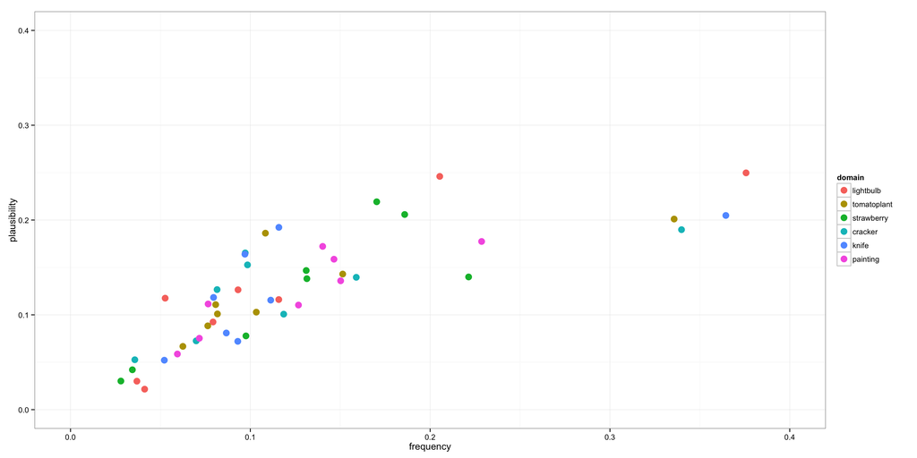

```r
ggplot(mean_cast,aes(x=frequency,y=plausibility,color=domain))+
geom_point(size=4)+
  theme_bw()+
  xlim(0,0.4)+
  ylim(0,0.4)
```

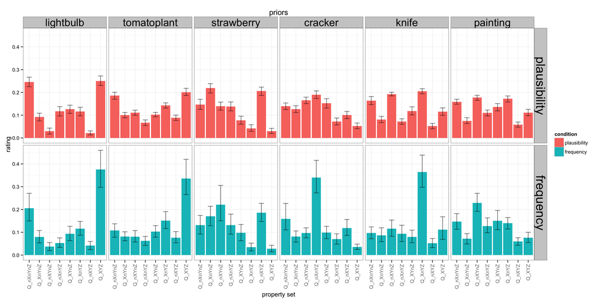

```r
ggplot(ci_bs, aes(x=variable, y=value, fill=condition)) +
  geom_bar(position=position_dodge(.6), stat='identity')+
    geom_errorbar(aes(ymin=YMin,ymax=YMax),width=0.5,alpha=0.6,
                position=position_dodge(.6))+
  xlab("property set")+
  ylab("rating")+
  facet_grid(condition~domain)+
  ggtitle("priors")+
  theme_bw()+
  theme(axis.text.x=element_text(angle=90,hjust=1,vjust=.5,colour='gray50'),
    strip.text.x = element_text(size=20),
    strip.text.y = element_text(size=24,angle=270))
```

NOTE: Properties on the X-axis are arranged from Absence of all properties (Left) to Presence of all proeprties (Right)

### dot plot

```r
df_nmelt<-melt(df_norm)
```

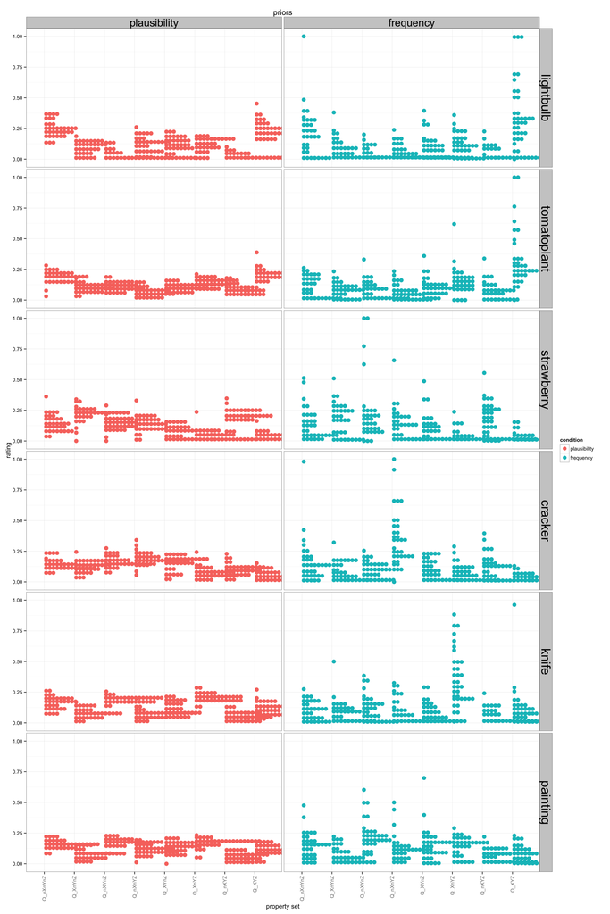

```r
df_nmelt$variable<-factor(df_nmelt$variable,
                          levels=c('Q_nXnYnZ','Q_XnYnZ','Q_nXYnZ',
                                'Q_nXnYZ','Q_XYnZ','Q_XnYZ','Q_nXYZ',
                                'Q_XYZ'))

df_nmelt$domain<-factor(df_nmelt$domain,
                     levels=c('lightbulb','tomatoplant','strawberry',
                              'cracker','knife','painting'))


ggplot(df_nmelt, aes(x=variable, y=value, colour=condition, fill=condition))+
  geom_dotplot(binaxis = "y", binwidth=.03, dotsize=1)+
  xlab("property set")+
  ylab("rating")+
  facet_grid(domain~condition)+
  ggtitle("priors")+
  theme_bw()+
  theme(axis.text.x=element_text(angle=90,hjust=1,vjust=.5,colour='gray50'),    strip.text.x = element_text(size=20),
    strip.text.y = element_text(size=24,angle=270))
```

OED stuff

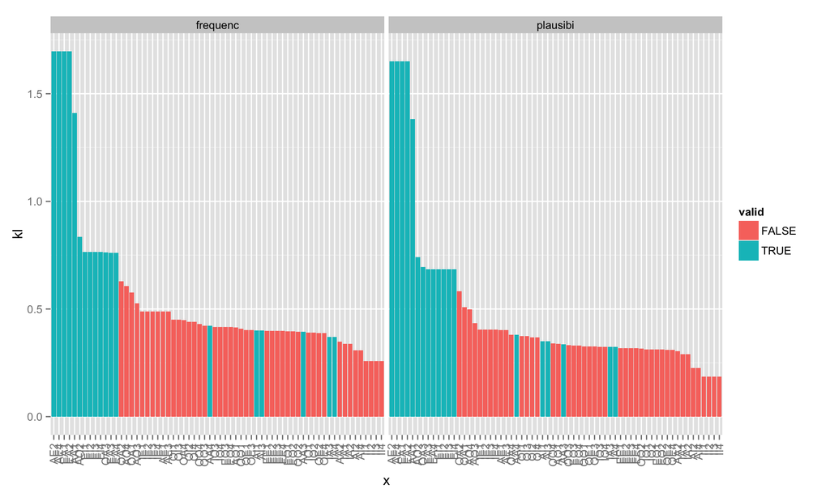

```r
fpath<-'/Users/mht/Documents/research/syllogism/data/03syllogism_prior_psychjs/'
oeds<-list.files(fpath,pattern='oed.*\\.txt')

oed.res = data.frame(syll=rep(NA,0),prior=rep(NA,0),
                        kl=rep(NA,0),valid=rep(NA,0),
                        stringsAsFactors=FALSE)

valid.ca <- read.table('/Users/mht/Documents/research/syllogism/models/metadata/allvalidmoodsCA.txt',header=TRUE)

for (o in oeds){
  df.tm <- read.table(paste(fpath,o,sep=''),col.names=c('syll','kl'))
  df.tm$valid<-df.tm$syll%in%valid.ca$syll
  df.tm$prior<-substr(o,5,12)
  df.tm$syll<- factor(df.tm$syll,levels=df.tm$syll[order(df.tm$kl)])
  oed.res<-rbind(oed.res,df.tm)
}


oed.res$syll = as.character(oed.res$syll)
oed.res$n = as.numeric(factor(oed.res$prior))

oed.res = ddply(oed.res, .(syll,valid,prior), transform,
                x=paste(c(rep(' ',n-1), syll), collapse=''))

oed.res$x = factor(oed.res$x, levels=oed.res[order(-oed.res$kl), 'x'])

ggplot(data=oed.res,aes(x=x,y=kl,fill=valid))+
  geom_bar(stat='identity')+
  facet_wrap(~prior,scale='free_x')+
  theme(axis.text.x=element_text(angle=90,hjust=1,vjust=.5,colour='gray50'))
```

Good to see that these basically look the same.

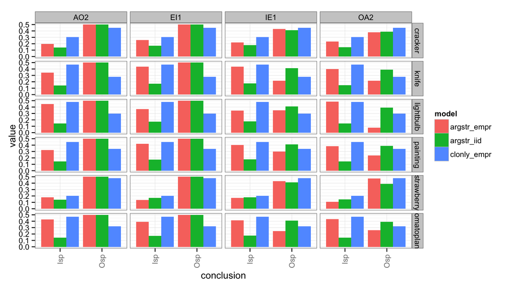